# 02_cpolys_new_v2

This notebook pulls in circuit polygon data from PG&E and SCE and analyzes clipping in ArcGIS (performing some basic sanity checks). Version new v2: Changed the data for number of SCE customers, based on historic data given by the Grid Limits paper. Better estimation of customer.

```r
library(tidyverse)
library(tictoc)
library(reshape2)
library(ggplot2)
library(stringr)
library(tidytext)
library(measurements) # https://cran.r-project.org/web/packages/measurements/measurements.pdf
library(readxl)
library(colorspace)
library(cowplot)
```

SCE

Circuit segment polygons

```r
setwd('C:/Users/Louis Rosset/Documents/EPFL/Master Project/QGIS_data/02_cpolys/IOUdata/SCE')
SCE_cspoly = read.csv("SCE_ICAall_cspoly.csv", header=T, na.strings="null", colClasses=c(rep("integer",2), "character", "numeric", rep("integer",2), "numeric", rep("character",3), rep("numeric",5), "character", "factor", "numeric", rep("character",3), "numeric", "character", rep("numeric",8), rep("integer",4), "numeric", rep("character",3), rep("numeric", 13)))

colnames(SCE_cspoly) <- c("FID", "LineSeg", "CircuitName", "SectionId", "NodeId", "Phase", "CircVolt_kV", "Substation", "Subst_kV", "System", "ICL", "ICPVOF", "ICPV", "ICUGOF", "ICUG", "DwnldLink", "Note", "ObjectId", "Disclaimer", "ChangedDate", "DownloadLinkMicrogrid", "Length_m", "CircName", "Res_pct", "Com_pct", "Agr_pct", "Ind_pct", "Oth_pct", "ExistDG", "QueueDG", "TotalDG",
"STATEFP", "COUNTYFP", "TRACTCE", "BLKGRPCE", "GEOID", "NAMELSAD", "MTFCC", "FUNCSTAT", "ALAND", "AWATER", "INTPTLAT", "INTPTLON", "InhArea", "OrigArea", "InhArea_Wt", "SCEarea", "SCEarea_Wt", "CpolyA", "CpolyA_Wt", "Shape_Len", "ShapeArea")

SCE_cspoly$GEOID <- paste0("0", SCE_cspoly$GEOID)

#CHANGE
SCE_cspoly <- SCE_cspoly %>% unique() %>%
  select(-c("Disclaimer", "DownloadLinkMicrogrid", "Shape_Len","MTFCC","FUNCSTAT", "ICPVOF", "ICPV", "ICUGOF", "ICUG")) %>%
  mutate(IOU = "SCE")

summary(as.factor(SCE_cspoly$LineSeg))
```

Circuit / block group polygons

```r
setwd('C:/Users/Louis Rosset/Documents/EPFL/Master Project/QGIS_data/02_cpolys/IOUdata/SCE')
SCE_cpolybg = read.csv("SCE_ICAall_cpolybg.csv", header=T, na.strings="null", colClasses=c("integer", "character", rep("integer", 3), "numeric", rep("character",3), rep("numeric",20), rep("numeric",9), rep("integer",3), "character", rep("numeric",13)))

SCE_clsstats <- SCE_cspoly %>% select(LineSeg, CircuitName, GEOID) %>%
  mutate(CLS = ifelse(LineSeg==0,NA,LineSeg),
         CircuitName = toupper(CircuitName)) %>%
  group_by(CircuitName, GEOID) %>%
  summarise(CLSmax = max(CLS, na.rm=TRUE), CLSavg = mean(CLS, na.rm=TRUE), CLSmin = min(CLS, na.rm=TRUE))


colnames(SCE_cpolybg) <- c("FID", "CircuitName", "CircuitNum", "Phase_max", "Phase_min",
                "CircVolt_kV", "Substation", "Subst_kV", "System",
                "ICL_max", "ICL_avg", "ICL_min", "ICL_std",
                "ICPVOF_max", "ICPVOF_avg", "ICPVOF_min", "ICPVOF_std",
                "ICPV_max", "ICPV_avg", "ICPV_min", "ICPV_std",
                "ICUGOF_max", "ICUGOF_avg", "ICUGOF_min", "ICUGOF_std",
                "ICUG_max", "ICUG_avg", "ICUG_min", "ICUG_std",
                "Length_m",
                "Res_pct","Com_pct", "Agr_pct", "Ind_pct", "Oth_pct", "ExistDG", "QueueDG", "TotalDG",
                "CountyId", "TractId", "BlkgId", "GEOID",
                "ALAND", "AWATER", "Intptlat", "Intptlon",
                "OrigArea", "InhArea", "InhArea_Wt", "SCEarea",
                "SCEarea_Wt", "CpolyA", "CpolyA_Wt", "Shape_Length", "Shape_Area")

SCE_cpolybg <- SCE_cpolybg %>% unique() %>%
  mutate(CircuitName = toupper(CircuitName), IOU = "SCE") %>%
  merge(SCE_clsstats, by=c("GEOID","CircuitName"), all.x=TRUE) %>%
  select(-c("ICPVOF_max", "ICPVOF_avg", "ICPVOF_min", "ICPVOF_std",
                "ICPV_max", "ICPV_avg", "ICPV_min", "ICPV_std",
                "ICUGOF_max", "ICUGOF_avg", "ICUGOF_min", "ICUGOF_std",
                "ICUG_max", "ICUG_avg", "ICUG_min", "ICUG_std"))

is.na(SCE_cpolybg) <- do.call(cbind,lapply(SCE_cpolybg, is.infinite))
```

Full circuit polygons

```r
setwd('C:/Users/Louis Rosset/Documents/EPFL/Master Project/QGIS_data/02_cpolys/IOUdata/SCE')
SCE_ctotpoly = read.csv("SCE_ICAall_ctotpoly.csv", header=T, na.strings="null", colClasses=c("integer", "character", rep("numeric",3), rep("character",3), rep("numeric",20), rep("numeric",12)))

setwd('C:/Users/Louis Rosset/Documents/EPFL/Master Project/QGIS_data/01_utilitydata/IOUdata/SCE')
SCE_circcust = read_excel("GridLimits_paper_data/2012-2017CircuitCustomerBase.xlsx", sheet=1, na="NA")
names(SCE_circcust) <- c("Year", "CircuitNo", "CircuitNum", "CircuitName", "CustBase")

setwd('C:/Users/Louis Rosset/Documents/EPFL/Master Project/QGIS_data/01_utilitydata/IOUdata/SCE')
SCE_RAM_Circuits = read.csv("SCE_RAM_Circuits.csv", header=T, na.strings="?")
SCE_RAM_Circuits <- SCE_RAM_Circuits %>%
  dplyr::rename("CircuitName"="CIRCUIT_NAME", "Substation"="SUB_NAME", "ExistGen_MW"="EXISTING_GEN", "QueueGen_MW"="QUEUED_GEN", "TotalGen_MW"="TOTAL_GEN",
                     "ProjLoad_MW"="PROJECTED_LOAD", "CurrPen_Pct"="PENETRATION_LEVEL", "MxRemGen_MW"="MAX_REMAIN_CAP", "x15PenCp_MW"="PERCENT_15_CAP", "DelivNote"="NOTE") %>%
 mutate(CircuitName = toupper(CircuitName))

SCE_clsstats <- SCE_cspoly %>% select(LineSeg, CircuitName) %>%
  mutate(CLS = ifelse(LineSeg==0,NA,LineSeg),
         CircuitName = toupper(CircuitName)) %>%
  group_by(CircuitName) %>%
  summarise(CLSmax = max(CLS, na.rm=TRUE), CLSavg = mean(CLS, na.rm=TRUE), CLSmin = min(CLS, na.rm=TRUE))

colnames(SCE_ctotpoly) <- c("FID", "CircuitName", "Phase_max", "Phase_min",
                "CircVolt_kV", "Substation", "Subst_kV", "System",
                "ICL_max", "ICL_avg", "ICL_min", "ICL_std",
                "ICPVOF_max", "ICPVOF_avg", "ICPVOF_min", "ICPVOF_std",
                "ICPV_max", "ICPV_avg", "ICPV_min", "ICPV_std",
                "ICUGOF_max", "ICUGOF_avg", "ICUGOF_min", "ICUGOF_std",
                "ICUG_max", "ICUG_avg", "ICUG_min", "ICUG_std",
                "Length_m_ctot",
                "Res_pct", "Com_pct", "Agr_pct", "Ind_pct",
                "Oth_pct", "ExistDG", "QueueDG", "TotalDG",
                "CtotpolyA", "Shape_Length", "Shape_Area")

SCE_ctotpoly <- SCE_ctotpoly %>% unique() %>%
  mutate(CircuitName = toupper(CircuitName), IOU = "SCE") %>%
  merge(SCE_clsstats, by=c("CircuitName"), all.x=TRUE) %>%
  select(-c("ICPVOF_max", "ICPVOF_avg", "ICPVOF_min", "ICPVOF_std",
                "ICPV_max", "ICPV_avg", "ICPV_min", "ICPV_std",
                "ICUGOF_max", "ICUGOF_avg", "ICUGOF_min", "ICUGOF_std",
                "ICUG_max", "ICUG_avg", "ICUG_min", "ICUG_std")) %>%
  #merge(SCE_circcust[ , c("CircuitName", "TotCust", "AgrCust", "ComCust", "IndCust", "ResCust", "OthCust")], by="CircuitName", all.x=TRUE)
  merge( filter(SCE_circcust, Year==2015)[ , c("CircuitName", "CustBase")], by="CircuitName", all.x=TRUE) %>%
  dplyr::rename("CustBase2015"="CustBase") %>%
  merge( filter(SCE_circcust, Year==2017)[ , c("CircuitName", "CustBase")], by="CircuitName", all.x=TRUE) %>%
  dplyr::rename("CustBase2017"="CustBase") %>%
  mutate(CustRes2015 = CustBase2015 * Res_pct /100,
         CustRes2017 = CustBase2017 * Res_pct /100)

is.na(SCE_ctotpoly) <- do.call(cbind,lapply(SCE_ctotpoly, is.infinite))

# how many circuit segments don't have a match?
nrow(subset(SCE_ctotpoly, is.na(CustBase2015)))
nrow(subset(SCE_ctotpoly, is.na(CustBase2017)))

SCE_ctotpoly <- SCE_ctotpoly %>%
  merge(SCE_RAM_Circuits[ , c("CircuitName", "Substation", "ExistGen_MW", "QueueGen_MW", "TotalGen_MW",
                     "ProjLoad_MW", "CurrPen_Pct", "MxRemGen_MW", "x15PenCp_MW", "DelivNote")],
        by = c("CircuitName","Substation"), all.x=TRUE) %>% unique() %>%
        dplyr::rename("ResCust"="CustRes2017")


# Update text for deliverability note:
summary(SCE_ctotpoly$DelivNote)
SCE_ctotpoly$DelivNote <- factor(SCE_ctotpoly$DelivNote)
levels(SCE_ctotpoly$DelivNote)
levels(SCE_ctotpoly$DelivNote)[1] <- "Undetermined"
levels(SCE_ctotpoly$DelivNote)[2] <- "Adequate"
levels(SCE_ctotpoly$DelivNote)[3] <- "Inadequate"
levels(SCE_ctotpoly$DelivNote)

SCE_cpolybg <- SCE_cpolybg %>%
  merge(SCE_ctotpoly[ , c("CircuitName", "CLSmax", "CLSavg", "CLSmin", "ICL_max", "ICL_avg", "ICL_min",
                          "CtotpolyA", "Length_m_ctot",
                          "CustBase2015", "CustBase2017", "CustRes2015", "ResCust",
                          "ExistGen_MW", "QueueGen_MW", "TotalGen_MW", "ProjLoad_MW", "CurrPen_Pct",
                          "MxRemGen_MW", "x15PenCp_MW", "DelivNote")],
                     by=c("CircuitName"), suffixes = c("","_ctot"), all.x=TRUE) %>%
  mutate(Length_Wt = Length_m / Length_m_ctot) %>% unique()

summary(SCE_cpolybg[, c("Length_m", "Length_m_ctot", "Length_Wt")])
```

PG&E

Circuit segment polygons

```r
setwd('C:/Users/Louis Rosset/Documents/EPFL/Master Project/QGIS_data/02_cpolys/IOUdata/PGE')
PGE_cspoly = read.csv("PGE_ICA23_cspoly.csv", header=T, sep = ",", na.strings="null", colClasses = c(rep("integer",3), rep("character",2), "integer", "character", rep("numeric",6), "integer", "numeric", "integer", "character", "integer", "character", rep("factor",2), rep("numeric",8), "integer", rep("numeric",14), rep("character",3), rep("numeric",2), rep("character",2), rep("numeric",8)))

colnames(PGE_cspoly) <- c("CircuitId", "CircuitNum", "FeederID", "CircuitName", "GlobalId",
                "LineSegId", "ICAanalysis", "ICL", "UGOF", "PVOF", "UG", "PV",
                "ShapeLen", "ICAavail", "Length_m",
                "FeederNum", "Substation", "FeederId", "CircName",
                "Nominal_kV", "LoadProfile",
                "ResCust", "ComCust", "IndCust", "AgrCust", "OthCust",
                "ExistDG", "QueueDG", "TotalDG",
                "Show", "CircVolt_kV", "LenCtot_m",
                "CustTot", "Res_pct", "Com_pct", "Ind_pct", "Agr_pct", "Oth_pct",
                "SubstationID", "StateId", "CountyId", "TractId",
                "BlkgId", "GEOID10", "BlockGroup", "MTFCC", "FuncStat",
                "ALAND", "AWATER", "Intptlat", "Intptlon",
                "InhArea", "OrigArea", "InhArea_Wt", "PGEarea",
                "PGEarea_Wt", "Shape_Area", "CpolyA", "CpolyA_Wt")

PGE_cspoly <- PGE_cspoly %>%
  select(-c("UGOF", "PVOF", "UG", "PV")) %>%
  mutate(Agr_pct=Agr_pct*100, Com_pct=Com_pct*100, Ind_pct=Ind_pct*100, Res_pct=Res_pct*100, Oth_pct=Oth_pct*100) %>%
  mutate(ICAanalysis=factor(ICAanalysis, levels=c("Mar 2020", "Apr 2020", "May 2020", "Jun 2020", "Jul 2020", "Aug 2020", "Sep 2020", "Oct 2020", "Nov 2020", "Dec 2020",
    "Jan 2021", "Feb 2021", "Mar 2021", "Apr 2021", "May 2021", "Jun 2021", "Jul 2021", "Aug 2021", "Sep 2021", "Oct 2021", "Nov 2021", "Dec 2021",
    "Jan 2022", "Feb 2022", "Mar 2022", "Apr 2022", "May 2022", "Jun 2022", "Jul 2022", "Aug 2022", "Sep 2022", "Oct 2022", "Nov 2022", "Dec 2022",
    "Jan 2023", "Feb 2023", "Mar 2023", "Apr 2023", "May 2023", "Jun 2023", "Jul 2023", "Aug 2023")),
         IOU = "PGE")

summary(PGE_cspoly$ICAanalysis)

PGE_ICAavailability <- (sum(PGE_cspoly$ICAavail == 1) / nrow(PGE_cspoly)) * 100
print(paste("Percentage of all circuit segments (distributed throughout its territory):", PGE_ICAavailability, "%"))
```

Circuit / block group polygons

```r
setwd('C:/Users/Louis Rosset/Documents/EPFL/Master Project/QGIS_data/02_cpolys/IOUdata/PGE')
PGE_cpolybg = read.csv("PGE_ICA23_cpolybg.csv", header=T, sep = ",", na.strings="null", colClasses=c("integer", "character", "integer", rep("numeric",20), "integer", rep("numeric",2), "integer", rep("character",2), rep("numeric",16), rep("integer",3), rep("numeric",3), rep("character",2), rep("numeric",9)))

PGE_cpolybgICA = read.csv("PGE_ICA23_cpolybg_ICAavail.csv", header=T, sep = ",", na.strings="null", colClasses=c("integer", "character", "numeric", "integer", rep("numeric",20), "numeric", "integer", rep("character",2), rep("numeric",16), rep("integer",3), rep("numeric",3), rep("character",2), rep("numeric",9)))

colnames(PGE_cpolybg) <- c("CircuitNum", "CircuitName", "CircuitId",
                "ICL_max", "ICL_avg", "ICL_min", "ICL_std",
                "ICUGOF_max", "ICUGOF_avg", "ICUGOF_min", "ICUGOF_std",
                "ICPVOF_max", "ICPVOF_avg", "ICPVOF_min", "ICPVOF_std",
                "ICUG_max", "ICUG_avg", "ICUG_min", "ICUG_std",
                "ICPV_max", "ICPV_avg", "ICPV_min", "ICPV_std",
                "CScount", "CSwICA", "Length_m",
                "SubId", "Substation", "Nominal_kV",
                "ResCust", "ComCust", "IndCust", "AgrCust",
                "OthCust", "ExistDG", "QueueDG", "TotalDG",
                "CircVolt_kV", "LenCtot_m", "CustTot",
                "Res_pct", "Com_pct", "Ind_pct", "Agr_pct", "Oth_pct",
                "CountyId", "TractId", "BlkgId", "GEOID",
                "ALAND", "AWATER", "Intptlat", "Intptlon",
                "OrigArea", "InhArea", "InhArea_Wt", "PGEarea",
                "PGEarea_Wt", "CpolyA", "ShapeLength", "ShapeArea", "CpolyA_Wt")

PGE_cpolybg <- PGE_cpolybg %>% unique() %>%
  select(-c("ICUGOF_max", "ICUGOF_avg", "ICUGOF_min", "ICUGOF_std",
                "ICPVOF_max", "ICPVOF_avg", "ICPVOF_min", "ICPVOF_std",
                "ICUG_max", "ICUG_avg", "ICUG_min", "ICUG_std",
                "ICPV_max", "ICPV_avg", "ICPV_min", "ICPV_std")) %>%
  mutate(Agr_pct=Agr_pct*100, Com_pct=Com_pct*100, Ind_pct=Ind_pct*100, Res_pct=Res_pct*100, Oth_pct=Oth_pct*100) %>%
  mutate(IOU = "PGE")

colnames(PGE_cpolybgICA) <- c("CircuitNum", "CircuitName", "GEOID10", "CircuitId",
                "ICL_max", "ICL_avg", "ICL_min", "ICL_std",
                "ICUGOF_max", "ICUGOF_avg", "ICUGOF_min", "ICUGOF_std",
                "ICPVOF_max", "ICPVOF_avg", "ICPVOF_min", "ICPVOF_std",
                "ICUG_max", "ICUG_avg", "ICUG_min", "ICUG_std",
                "ICPV_max", "ICPV_avg", "ICPV_min", "ICPV_std",
                "Length_m",
                "SubId", "Substation", "Nominal_kV",
                "ResCust", "ComCust", "IndCust", "AgrCust",
                "OthCust", "ExistDG", "QueueDG", "TotalDG",
                "CircVolt_kV", "LenCtot_m", "CustTot",
                "Res_pct", "Com_pct", "Ind_pct", "Agr_pct", "Oth_pct",
                "CountyId", "TractId", "BlkgId", "GEOID",
                "ALAND", "AWATER", "Intptlat", "Intptlon",
                "OrigArea", "InhArea", "InhArea_Wt", "PGEarea",
                "PGEarea_Wt", "CpolyA", "ShapeLength", "ShapeArea", "CpolyA_Wt")

PGE_cpolybgICA <- PGE_cpolybgICA %>% unique() %>%
  select(-c("ICUGOF_max", "ICUGOF_avg", "ICUGOF_min", "ICUGOF_std",
                "ICPVOF_max", "ICPVOF_avg", "ICPVOF_min", "ICPVOF_std",
                "ICUG_max", "ICUG_avg", "ICUG_min", "ICUG_std",
                "ICPV_max", "ICPV_avg", "ICPV_min", "ICPV_std")) %>%
  mutate(Agr_pct=Agr_pct*100, Com_pct=Com_pct*100, Ind_pct=Ind_pct*100, Res_pct=Res_pct*100, Oth_pct=Oth_pct*100) %>%
  mutate(IOU = "PGE")
```

Full circuit polygons

```r
setwd('C:/Users/Louis Rosset/Documents/EPFL/Master Project/QGIS_data/02_cpolys/IOUdata/PGE')
PGE_ctotpoly = read.csv("PGE_ICA23_ctotpoly.csv", header=T, sep = ",", na.strings="null", colClasses=c("integer", "character", "integer", rep("numeric",20), "integer", rep("numeric",2), "integer", rep("character",2), rep("numeric",19)))

setwd('C:/Users/Louis Rosset/Documents/EPFL/Master Project/QGIS_data/01_utilitydata/IOUdata/PGE/circuitfiles')
PGE_subs = read.csv("PGE_subs.csv", header=T, na.strings="?", colClasses=c("character", rep("integer",2), rep("numeric",2), "factor", "integer", rep("character",4), rep("numeric",4)))

colnames(PGE_ctotpoly) <- c("CircuitNum", "CircuitName", "CircuitId",
                "ICL_max", "ICL_avg", "ICL_min", "ICL_std",
                "ICUGOF_max", "ICUGOF_avg", "ICUGOF_min", "ICUGOF_std",
                "ICPVOF_max", "ICPVOF_avg", "ICPVOF_min", "ICPVOF_std",
                "ICUG_max", "ICUG_avg", "ICUG_min", "ICUG_std",
                "ICPV_max", "ICPV_avg", "ICPV_min", "ICPV_std",
                "CScount", "CSwICA", "Length_m",
                "SubId", "Substation", "Nominal_kV",
                "ResCust", "ComCust", "IndCust", "AgrCust",
                "OthCust", "ExistDG", "QueueDG", "TotalDG",
                "CircVolt_kV", "LenCtot_m", "CustTot",
                "Res_pct", "Com_pct", "Ind_pct", "Agr_pct", "Oth_pct",
                "CtotpolyA", "ShapeLength", "ShapeArea")

PGE_ctotpoly <- PGE_ctotpoly %>%
  select(-c("ICUGOF_max", "ICUGOF_avg", "ICUGOF_min", "ICUGOF_std",
                "ICPVOF_max", "ICPVOF_avg", "ICPVOF_min", "ICPVOF_std",
                "ICUG_max", "ICUG_avg", "ICUG_min", "ICUG_std",
                "ICPV_max", "ICPV_avg", "ICPV_min", "ICPV_std")) %>%
  mutate(Agr_pct=Agr_pct*100, Com_pct=Com_pct*100, Ind_pct=Ind_pct*100, Res_pct=Res_pct*100, Oth_pct=Oth_pct*100) %>%
  mutate(IOU = "PGE") %>%
  merge(PGE_subs[,c("Substation","Min_kV","N_banks","Division","LCRarea","Owner", "SAIDI3a5yravg","SAIFI3a5yravg","MAIFI3a5yravg","CAIDI3a5yravg")], by="Substation", suffixes=c("","_sub"), all.x=TRUE) %>% unique()

PGE_cpolybg <- PGE_cpolybg %>%
  merge(PGE_ctotpoly[ , c("CircuitName", "ICL_max", "ICL_avg", "ICL_min",
                          "Length_m", "CtotpolyA", "Division", "LCRarea", "Owner",
                          "SAIDI3a5yravg", "SAIFI3a5yravg", "MAIFI3a5yravg", "CAIDI3a5yravg")],
        by=c("CircuitName"), suffixes = c("","_ctot"), all.x=TRUE) %>%
  mutate(Length_Wt = Length_m / Length_m_ctot) %>% unique()
summary(PGE_cpolybg[, c("Length_m", "Length_m_ctot", "Length_Wt")])
```

```
    Length_m        Length_m_ctot        Length_Wt
 Min.   :     0.6   Min.   :     5.4   Min.   :0.0000124
 1st Qu.:   665.6   1st Qu.: 26647.9   1st Qu.:0.0173988
 Median :  2088.1   Median : 53651.3   Median :0.0487559
 Mean   :  6455.4   Mean   : 75666.1   Mean   :0.0888848
 3rd Qu.:  6025.7   3rd Qu.: 95795.2   3rd Qu.:0.1095738
 Max.   :210460.5   Max.   :725711.6   Max.   :1.0000000
```

```r
PGE_cpolybgICA <- PGE_cpolybgICA %>%
  merge(PGE_ctotpoly[ , c("CircuitName", "ICL_max", "ICL_avg", "ICL_min",
                          "Length_m", "CtotpolyA", "Division", "LCRarea", "Owner",
                          "SAIDI3a5yravg", "SAIFI3a5yravg", "MAIFI3a5yravg", "CAIDI3a5yravg")],
        by=c("CircuitName"), suffixes = c("","_ctot"), all.x=TRUE) %>%
  mutate(Length_Wt = Length_m / Length_m_ctot) %>% unique()

summary(PGE_cpolybgICA[, c("Length_m", "Length_m_ctot", "Length_Wt")])
```

```
    Length_m         Length_m_ctot        Length_Wt
 Min.   :     1.69   Min.   :     5.4   Min.   :0.0000124
 1st Qu.:   615.36   1st Qu.: 28418.9   1st Qu.:0.0141332
 Median :  1607.79   Median : 54457.8   Median :0.0348909
 Mean   :  4531.62   Mean   : 75861.6   Mean   :0.0671598
 3rd Qu.:  3954.74   3rd Qu.: 95680.2   3rd Qu.:0.0753007
 Max.   :175007.01   Max.   :725711.6   Max.   :1.0000000
```

Do individual circuit polygons add up to 100% of potentially-inhabited area? Do circuit line segments add up to 100% of circuit line lengths?

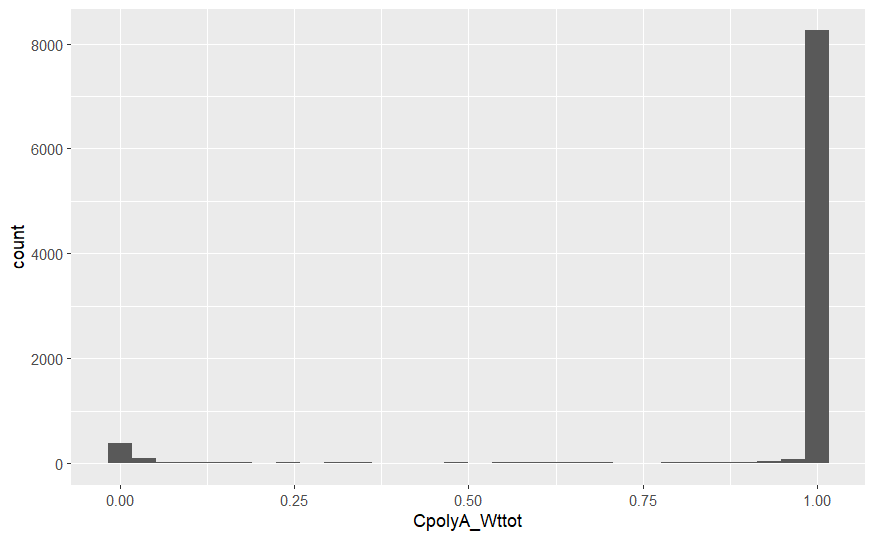

```r
SCE_cpolybg %>% group_by(GEOID) %>% summarise(CpolyA_Wttot = sum(CpolyA_Wt, na.rm=TRUE)) %>%
  ggplot( aes(x=CpolyA_Wttot)) + geom_histogram()
```

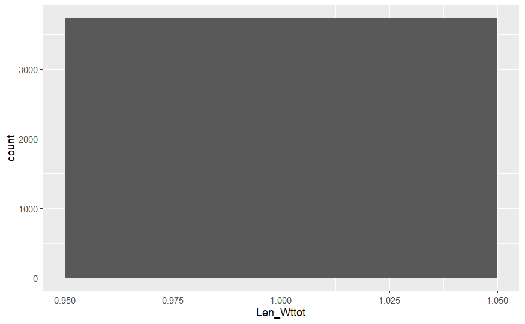

```r
SCE_cpolybg %>% group_by(CircuitName) %>% summarise(Len_Wttot = sum(Length_Wt, na.rm=TRUE)) %>%
  ggplot( aes(x=Len_Wttot)) + geom_histogram()
```

```r
SCE_cpolybg %>% group_by(CircuitName) %>% summarise(Len_Wttot = sum(Length_Wt, na.rm=TRUE)) %>% filter(Len_Wttot>1.000001)
```

| CircuitName | Len_Wttot |
| --- | --- |

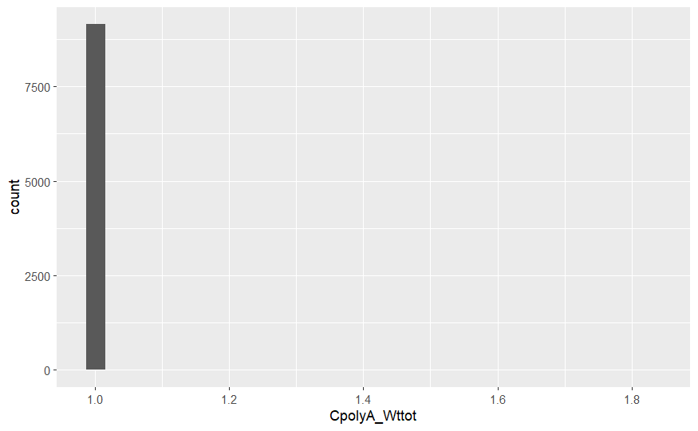

```r
PGE_cpolybg %>% group_by(GEOID) %>% summarise(CpolyA_Wttot = sum(CpolyA_Wt, na.rm=TRUE)) %>%
  ggplot( aes(x=CpolyA_Wttot)) + geom_histogram()
```

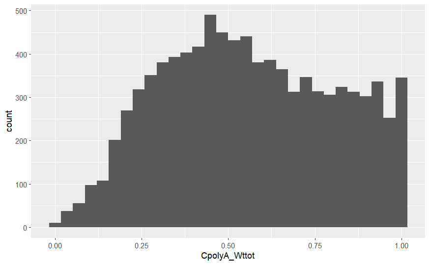

```r
PGE_cpolybgICA %>% group_by(GEOID) %>% summarise(CpolyA_Wttot = sum(CpolyA_Wt, na.rm=TRUE)) %>%
  ggplot( aes(x=CpolyA_Wttot)) + geom_histogram()
```

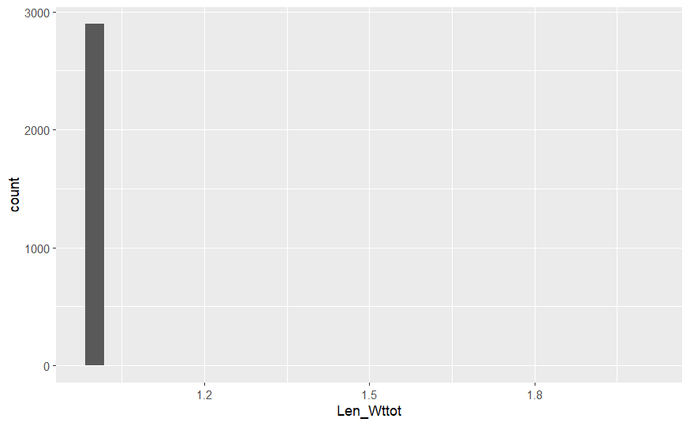

```r
PGE_cpolybg %>% group_by(CircuitName) %>% summarise(Len_Wttot = sum(Length_Wt, na.rm=TRUE)) %>%
  ggplot( aes(x=Len_Wttot)) + geom_histogram()
```

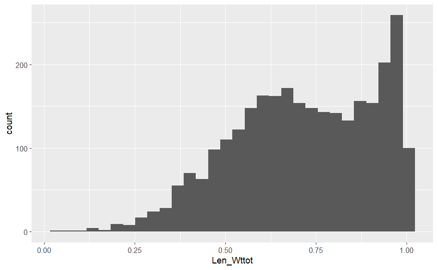

```r
PGE_cpolybgICA %>% group_by(CircuitName) %>% summarise(Len_Wttot = sum(Length_Wt, na.rm=TRUE)) %>%
  ggplot( aes(x=Len_Wttot)) + geom_histogram()
```

```r
PGE_cpolybgICA %>% group_by(CircuitName) %>% summarise(Len_Wttot = sum(Length_Wt, na.rm=TRUE)) %>% filter(Len_Wttot>1.000001)
```

| CircuitName | Len_Wttot |
| --- | --- |

We will proceed with this data, assuming the denominator of all size fractions is 1. It makes sense that the PGE_cpolybgICA graphs do not cluster around 1, as they consider only the portions of circuits/block groups for which PG&E provides ICA information.

```r
PGE_cpolybg <- PGE_cpolybg %>% mutate(ICA_pct = CSwICA/CScount)

PGE_cpolybgICA <- PGE_cpolybgICA %>%
  merge(PGE_cpolybg[,c("CircuitName","GEOID","ICA_pct")], by=c("CircuitName","GEOID"), all.x=TRUE) %>% unique()
```

CIRCUIT POPULATION AND DEMOGRAPHICS

Demographic info, created via CensusDataAggregation.Rmd

```r
setwd('C:/Users/Louis Rosset/Documents/EPFL/Master Project/QGIS_data/Aggregate_Data_updated/')
demotypes = read.csv("bgCAcensusCESclasses.csv", header=T, na.strings="?")
bgCAcensusCES = read.csv("bgCAcensusCES.csv", header=T, na.strings="?", colClasses=as.character(demotypes$x))

colnames(bgCAcensusCES)[colnames(bgCAcensusCES) == "GEOID10"] <- "GEOID"
```

MERGING IN POPULATION INFO

Create new columns for numbers of people, households, and structures in each circuit polygon, and per length of circuit line: (Here, we first scale by the amount of area that’s in SCE’s territory, then assume that all of that is reallocated to inhabited areas. Population is not scaled by InhArea_Wt because that’s a spatial measure, not a measure of population shrinkage. Population is scaled by CpolyAtot_Wt, which is a fraction of the amount of inhabited area that circuit polygon represents.)

```r
SCE_cpolybg$GEOID <- substring(SCE_cpolybg$GEOID, 2)
SCE_ICAall <- SCE_cpolybg %>%
  merge(bgCAcensusCES[,c("GEOID","tothh","totpop","totstr","county","zip_ct","nearbycity")], by="GEOID", all.x=TRUE) %>%
  mutate(tothh_Cpoly = tothh * SCEarea_Wt * CpolyA_Wt,
         totpop_Cpoly = totpop * SCEarea_Wt * CpolyA_Wt,
         totstr_Cpoly = totstr * SCEarea_Wt * CpolyA_Wt) %>%
  mutate(tothh_perkm = tothh_Cpoly / Length_m *1000) %>% unique()

PGE_all <- PGE_cpolybg %>%
  merge(bgCAcensusCES[,c("GEOID","tothh","totpop","totstr","county","zip_ct","nearbycity")], by="GEOID", all.x=TRUE) %>%
  mutate(tothh_Cpoly = tothh * PGEarea_Wt * CpolyA_Wt,
         totpop_Cpoly = totpop * PGEarea_Wt * CpolyA_Wt,
         totstr_Cpoly = totstr * PGEarea_Wt * CpolyA_Wt) %>%
  mutate(tothh_perkm = tothh_Cpoly / Length_m *1000) %>% unique()

PGE_ICAall <- PGE_cpolybgICA %>%
  merge(bgCAcensusCES[,c("GEOID","tothh","totpop","totstr","county","zip_ct","nearbycity")], by="GEOID", all.x=TRUE) %>%
  mutate(tothh_Cpoly = tothh * PGEarea_Wt * CpolyA_Wt,
         totpop_Cpoly = totpop * PGEarea_Wt * CpolyA_Wt,
         totstr_Cpoly = totstr * PGEarea_Wt * CpolyA_Wt) %>%
  mutate(tothh_perkm = tothh_Cpoly / Length_m *1000) %>% unique()
```

CHECKING CIRCUIT-LEVEL POPULATION ALLOCATION

```r
SCEvals <- SCE_ICAall %>% group_by(CircuitName) %>%
  summarise(tothh_ctot = sum(tothh_Cpoly, na.rm=TRUE),
            totpop_ctot = sum(totpop_Cpoly, na.rm=TRUE),
            totstr_ctot = sum(totstr_Cpoly, na.rm=TRUE))

SCE_ctotpoly <- merge(SCE_ctotpoly, SCEvals, by=c("CircuitName"), all.x=TRUE)

SCE_ICAall <- SCE_ICAall %>%
  merge(SCEvals, by=c("CircuitName"), suffixes=c("","ctot"), all.x=TRUE) %>% unique() %>%
  mutate(tothh_pct = tothh_Cpoly / tothh_ctot,
         totpop_pct = totpop_Cpoly / totpop_ctot,
         totstr_pct = totstr_Cpoly / totstr_ctot)

summary(SCE_ICAall[,c("tothh_Cpoly","tothh_ctot","tothh_pct")])
```

```
  tothh_Cpoly         tothh_ctot       tothh_pct
 Min.   :   0.000   Min.   :   0.0   Min.   :0.000000
 1st Qu.:   9.261   1st Qu.: 771.2   1st Qu.:0.008416
 Median :  59.769   Median :1395.6   Median :0.050293
 Mean   : 118.040   Mean   :1516.3   Mean   :0.100935
 3rd Qu.: 173.193   3rd Qu.:2032.7   3rd Qu.:0.138316
 Max.   :1984.283   Max.   :7074.8   Max.   :1.000000
                                     NA's   :3
```

For PG&E, we can calculate the total number of people, households, and structures served by all circuits and by circuits with ICA information. Since we’re focusing our analysis on circuits with ICA info, we calculate the percent households against those served by circuits with ICA information.

```r
PGEvals <- PGE_all %>% group_by(CircuitName) %>%
  summarise(tothh_ctot = sum(tothh_Cpoly, na.rm=TRUE),
            totpop_ctot = sum(totpop_Cpoly, na.rm=TRUE),
            totstr_ctot = sum(totstr_Cpoly, na.rm=TRUE))

PGE_ctotpoly <- merge(PGE_ctotpoly, PGEvals, by=c("CircuitName"), all.x=TRUE)

PGEvals <- PGE_ICAall %>% group_by(CircuitName) %>%
  summarise(tothh_ctot = sum(tothh_Cpoly, na.rm=TRUE),
            totpop_ctot = sum(totpop_Cpoly, na.rm=TRUE),
            totstr_ctot = sum(totstr_Cpoly, na.rm=TRUE))

PGE_ctotpoly <- merge(PGE_ctotpoly, PGEvals, by=c("CircuitName"), suffixes=c("","ICA"), all.x=TRUE) %>%
  mutate(tothhICA_pct = tothh_ctotICA/tothh_ctot,
         totpopICA_pct = totpop_ctotICA/totpop_ctot,
         totstrICA_pct = totstr_ctotICA/totstr_ctot)

PGE_ICAall <- PGE_ICAall %>%
  merge(PGE_ctotpoly[ ,c("CircuitName","tothh_ctot","totpop_ctot","totstr_ctot",
                         "tothh_ctotICA","totpop_ctotICA","totstr_ctotICA",
                         "tothhICA_pct","totpopICA_pct","totstrICA_pct")], by="CircuitName", all.x=TRUE) %>%
  unique() %>%
  mutate(tothh_pct = tothh_Cpoly / tothh_ctotICA,
         totpop_pct = totpop_Cpoly / totpop_ctotICA,
         totstr_pct = totstr_Cpoly / totstr_ctotICA)

summary(PGE_ICAall[,c("tothh_Cpoly","tothh_ctot","tothh_ctotICA","tothh_pct","tothhICA_pct")])
```

```
  tothh_Cpoly         tothh_ctot       tothh_ctotICA        tothh_pct        tothhICA_pct
 Min.   :   0.000   Min.   :   0.009   Min.   :   0.009   Min.   :0.00000   Min.   :0.02966
 1st Qu.:   9.842   1st Qu.:1115.773   1st Qu.: 590.661   1st Qu.:0.01009   1st Qu.:0.45121
 Median :  44.352   Median :1983.822   Median :1099.083   Median :0.04533   Median :0.58054
 Mean   :  83.153   Mean   :2244.318   Mean   :1280.593   Mean   :0.09379   Mean   :0.60429
 3rd Qu.: 115.973   3rd Qu.:3203.023   3rd Qu.:1742.672   3rd Qu.:0.12156   3rd Qu.:0.75759
 Max.   :1396.731   Max.   :7280.086   Max.   :5806.881   Max.   :1.00000   Max.   :1.00000
```

Verifiying that total number of households and population still add up to reasonable totals:

```r
cat("SCE: We estimate that ",sum(SCE_ctotpoly$totpop_ctot, na.rm=TRUE)," people and ",sum(SCE_ctotpoly$tothh_ctot, na.rm=TRUE)," households are located in SCE's territory. SCE estimates their total customer base as ",sum(SCE_ctotpoly$CustBase2015, na.rm=TRUE)," and ",sum(SCE_ctotpoly$CustBase2017, na.rm=TRUE)," for 2015 and 2017, respectively, and their residential customer base as ",sum(SCE_ctotpoly$CustRes2015, na.rm=TRUE)," and ",sum(SCE_ctotpoly$ResCust, na.rm=TRUE)," for 2015 and 2017.")
```

```
SCE: We estimate that  13841333  people and  4356620  households are located in SCE's territory. SCE estimates their total customer base as  4732664  and  4803331  for 2015 and 2017, respectively, and their residential customer base as  3349374  and  3399295  for 2015 and 2017.
```

```r
cat(" PG&E: We estimate that ",sum(PGE_ctotpoly$totpop_ctot, na.rm=TRUE)," people and ",sum(PGE_ctotpoly$tothh_ctot, na.rm=TRUE)," households are located in PG&E's territory. PG&E estimates their total customer base as ",sum(PGE_ctotpoly$CustTot, na.rm=TRUE),", and their residential customer base as ",sum(PGE_ctotpoly$ResCust, na.rm=TRUE),". Of these, we estimate that ",sum(PGE_ctotpoly$totpop_ctotICA, na.rm=TRUE)," people and ",sum(PGE_ctotpoly$tothh_ctotICA, na.rm=TRUE)," households are served by circuit line segments with ICA information.")
```

[output not shown]

Validation graphs (Supplementary Figure S5(a))

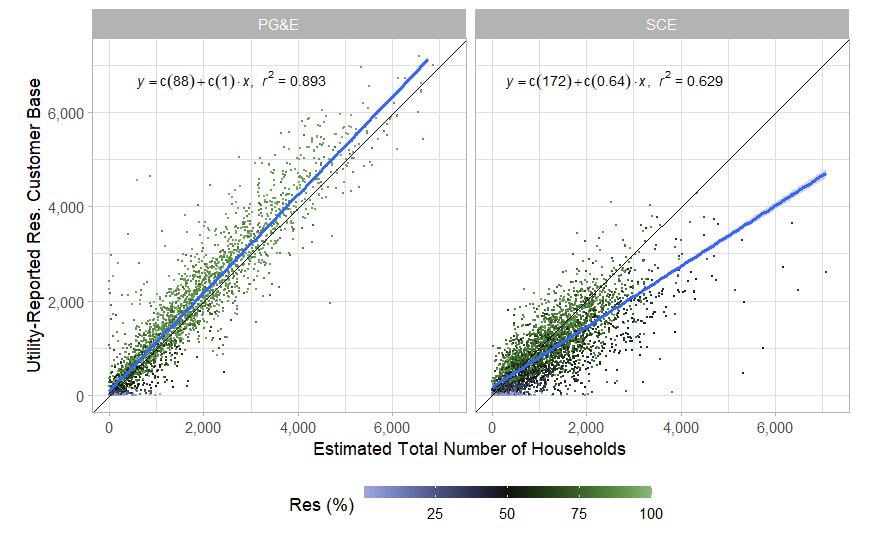

```r
cols <- c("IOU","CircuitName","ResCust","tothh_ctot","Res_pct")
df_PGE <- subset(PGE_ctotpoly[,cols], !is.na(ResCust))
df_SCE <- subset(SCE_ctotpoly[,cols], !is.na(ResCust))

lm_eqn_PGE <- function(df_PGE){ m <- lm(ResCust~tothh_ctot, data=df_PGE);
  eq <- substitute(italic(y) == a + b %.% italic(x)*","~~italic(r)^2~"="~r2,
          list(a=format(coef(m)[1], digits=2), b=format(coef(m)[2], digits=2),
          r2=format(summary(m)$r.squared, digits=3)))
  as.character(as.expression(eq));}

lm_eqn_SCE <- function(df_SCE){ m <- lm(ResCust~tothh_ctot, data=df_SCE);
  eq <- substitute(italic(y) == a + b %.% italic(x)*","~~italic(r)^2~"="~r2,
          list(a=format(coef(m)[1], digits=2), b=format(coef(m)[2], digits=2),
          r2=format(summary(m)$r.squared, digits=3)))
  as.character(as.expression(eq));}

ldata <- data.frame(label=c(lm_eqn_PGE(df_PGE), lm_eqn_SCE(df_SCE)), IOU=c("PGE","SCE"), x=c(2600,2600), y=c(6700,6700))

b <- rbind(df_PGE, df_SCE) %>%
  ggplot(aes(x=tothh_ctot, y=ResCust, color=Res_pct)) + facet_grid(~IOU, labeller=labeller(IOU=c(PGE="PG&E", SCE="SCE"))) +
  geom_point(size=0.2, alpha=1) + theme_light() +
  #scale_color_continuous_diverging(palette="Tofino", mid=50, l1=70, guide=guide_colourbar(barwidth=0.5, barheight=11)) +
  scale_color_continuous_diverging(palette="Tofino", mid=50, l1=70, guide=guide_colourbar(barwidth=12, barheight=0.5)) +
  scale_x_continuous(breaks=c(0,2000,4000,6000), labels=c("0","2,000","4,000","6,000"), limits=c(0,7200)) +
  scale_y_continuous(breaks=c(0,2000,4000,6000), labels=c("0","2,000","4,000","6,000"), limits=c(0,7200)) +
  #xlim(0,7200) + ylim(0,7200) +
  coord_fixed() + theme(legend.position="bottom") +
  geom_abline(intercept=0, slope=1) + geom_smooth(method='lm') +
  geom_text(data=ldata, aes(x=x, y=y, label=label), colour="black", parse=TRUE, size=3) +
  labs(x="Estimated Total Number of Households", y="Utility-Reported Res. Customer Base", color="Res (%)")
b

ggsave("IOU_ICAcirc19_ResCust_v_tothh_noNA.png", path="figures/", width=8, height=4)
```

```r
rm(ldata)
```

```r
plot_grid(b, a, labels=c('a','b'), label_size=12, rel_widths=c(1.8,1), rel_heights=c(1,0.6))
```

[output not shown]

SUBSETTING AND EXPORTING

How much of the data contains unrealistic population totals?

```r
poptoosmall = sum(subset(SCE_ICAall, totpop_Cpoly < 1, c(totpop_Cpoly)))
poptotal = sum(SCE_ICAall$totpop_Cpoly, na.rm=TRUE)
cat("SCE: The sum of population in Cpolys where the total pop is less than 1 is ",poptoosmall,". The total population in the dataset is ",poptotal,". That's ",poptoosmall/poptotal," of the data. Alternatively, ",(poptotal - poptoosmall) / poptotal," remains after removal.")
```

```
SCE: The sum of population in Cpolys where the total pop is less than 1 is  678.2735 . The total population in the dataset is  13841333 . That's  4.900348e-05  of the data. Alternatively,  0.999951  remains after removal.
```

```r
rm(poptoosmall)
hhtoosmall = sum(subset(SCE_ICAall, tothh_Cpoly < 1, c(tothh_Cpoly)))
hhtotal = sum(SCE_ICAall$tothh_Cpoly, na.rm=TRUE)
cat(" The total number of households in Cpolys where the number of households is less than 1 is ",hhtoosmall,". The total number of households in the dataset is ",hhtotal,". That's ",hhtoosmall/hhtotal," of the data. Alternatively, ",(hhtotal - hhtoosmall) / hhtotal," remains after removal.")
```

```
 The total number of households in Cpolys where the number of households is less than 1 is  1128.302 . The total number of households in the dataset is  4356620 . That's  0.0002589857  of the data. Alternatively,  0.999741  remains after removal.
```

```r
rm(hhtoosmall)

poptoosmall = sum(subset(PGE_ICAall, totpop_Cpoly < 1, c(totpop_Cpoly)))
poptotal = sum(PGE_ICAall$totpop_Cpoly, na.rm=TRUE)
cat(" PGE: The sum of population in Cpolys where the total pop is less than 1 is ",poptoosmall,". The total population in the dataset is ",poptotal,". That's ",poptoosmall/poptotal," of the data. Alternatively, ",(poptotal - poptoosmall) / poptotal," remains after removal.")
```

```
 PGE: The sum of population in Cpolys where the total pop is less than 1 is  528.3235 . The total population in the dataset is  7299544 . That's  7.23776e-05  of the data. Alternatively,  0.9999276  remains after removal.
```

```r
rm(poptoosmall)
hhtoosmall = sum(subset(PGE_ICAall, tothh_Cpoly < 1, c(tothh_Cpoly)))
hhtotal = sum(PGE_ICAall$tothh_Cpoly, na.rm=TRUE)
cat(" The total number of households in Cpolys where the number of households is less than 1 is ",hhtoosmall,". The total number of households in the dataset is ",hhtotal,". That's ",hhtoosmall/hhtotal," of the data. Alternatively, ",(hhtotal - hhtoosmall) / hhtotal," remains after removal.")
```

```
 The total number of households in Cpolys where the number of households is less than 1 is  804.2573 . The total number of households in the dataset is  2525780 . That's  0.0003184194  of the data. Alternatively,  0.9996816  remains after removal.
```

```r
rm(hhtoosmall)
```

Subset to remove unrealistic population totals:

```r
SCE_ICAall_real = subset(SCE_ICAall, tothh_Cpoly >= 1)
PGE_ICAall_real = subset(PGE_ICAall, tothh_Cpoly >= 1)
```

```r
setwd('C:/Users/Louis Rosset/Documents/EPFL/Master Project/QGIS_data/02_cpolys/IOUdata/PGE')
write.csv(PGE_cpolybg, file = "circuitfiles/PGE_cpolybg.csv", row.names=FALSE)
write.csv(PGE_cpolybgICA, file = "circuitfiles/PGE_cpolybgICA.csv", row.names=FALSE)
write.csv(PGE_ctotpoly, file = "circuitfiles/PGE_ctotpoly.csv", row.names=FALSE)
write.csv(PGE_all, file = "circuitfiles/PGE_all.csv", row.names=FALSE)
write.csv(PGE_ICAall, file = "PGE_ICAall.csv", row.names=FALSE)
write.csv(PGE_ICAall_real, file = "PGE_ICAallreal.csv", row.names=FALSE)
PGEtypes <- sapply(PGE_ICAall,class)
write.csv(PGEtypes, file = "circuitfiles/PGE_ICAallclasses.csv", row.names=FALSE)
PGEtypesall <- sapply(PGE_all,class)
write.csv(PGEtypesall, file = "circuitfiles/PGE_allclasses.csv", row.names=FALSE)

setwd('C:/Users/Louis Rosset/Documents/EPFL/Master Project/QGIS_data/02_cpolys/IOUdata/SCE')
write.csv(SCE_cpolybg, file = "circuitfiles/SCE_cpolybg.csv", row.names=FALSE)
write.csv(SCE_ctotpoly, file = "circuitfiles/SCE_ctotpoly.csv", row.names=FALSE)
write.csv(SCE_ICAall, file = "circuitfiles/SCE_ICAall.csv", row.names=FALSE)
write.csv(SCE_ICAall_real, file = "circuitfiles/SCE_ICAallreal.csv", row.names=FALSE)
SCEtypes <- sapply(SCE_ICAall,class)
write.csv(SCEtypes, file = "circuitfiles/SCE_ICAallclasses.csv", row.names=FALSE)
```